# Loan Default Risk

# Preliminary Data Analysis

```python
dataset.head()
```

|  | loan_amnt | term | int_rate | installment | grade | emp_length | home_ownership | annual_inc | verification_status | loan_status | ... | earliest_cr_line | open_acc | pub_rec | revol_bal | revol_util | total_acc | initial_list_status | application_type | mort_acc | pub_rec_bankruptcies |
| --- | --- | --- | --- | --- | --- | --- | --- | --- | --- | --- | --- | --- | --- | --- | --- | --- | --- | --- | --- | --- | --- |
| 0 | 5000 | 36 months | 7.35% | 155.19 | A | 5 years | MORTGAGE | 60000.0 | Not Verified | Fully Paid | ... | Oct-04 | 12 | 0 | 3697 | 13.20% | 25 | w | Individual | 1 | 0 |
| 1 | 7500 | 36 months | 7.35% | 232.79 | A | 7 years | MORTGAGE | 110000.0 | Not Verified | Fully Paid | ... | Mar-13 | 19 | 0 | 23348 | 27.20% | 27 | w | Individual | 4 | 0 |
| 2 | 9600 | 36 months | 7.97% | 300.70 | A | < 1 year | OWN | 140000.0 | Not Verified | Fully Paid | ... | Aug-05 | 16 | 0 | 11808 | 48.60% | 44 | w | Individual | 3 | 0 |
| 3 | 2000 | 36 months | 7.07% | 61.82 | A | 2 years | RENT | 80000.0 | Not Verified | Fully Paid | ... | Apr-05 | 9 | 0 | 38 | 0.30% | 12 | w | Individual | 0 | 0 |
| 4 | 7200 | 36 months | 24.85% | 285.70 | E | 2 years | RENT | 50000.0 | Source Verified | Fully Paid | ... | Jan-00 | 4 | 0 | 3560 | 98.90% | 5 | w | Individual | 0 | 0 |

5 rows × 23 columns

| Status | Count | Percentage |
| --- | --- | --- |
| Fully Paid | 29145 | 77% |
| Charged Off | 8625 | 23% |

A list of percentage of missing values in a column

```python
missing_values = ((dataset.isna().sum()) / len(dataset.index)).sort_values(ascending=False)
missing_values[missing_values > 0]
```

```
emp_length    0.065078
revol_util    0.000688
dti           0.000635
dtype: float64
```

| Variable | Type |
| --- | --- |
| Loan Amount | Numerical |
| Term | Categorical |
| Interest Rate | Numerical |
| Installment | Numerical |
| Grade | Categorical |
| Employment Length | Numerical |
| Home Ownership | Categorical |
| Annual Income | Numerical |
| Verification Status | Categorical |
| Loan Status | Categorical |
| Purpose | Categorical |
| Debt-to-Income Ratio | Numerical |
| Delinquency | Categorical |
| Earliest Credit Line | Numerical |
| Open Accounts | Numerical |
| Public Records | Categorical |
| Revolving Balance | Numerical |
| Revolving Utility | Numerical |
| Total Account | Numerical |
| Initial List Status | Categorical |
| Application Type | Categorical |
| Mortage Account | Numerical |
| Public Record of Bankruptcies | Categorical |

# Exploratory Data Analysis

### Annual Income (Numerical)

The self-reported annual income provided by the borrower during registration

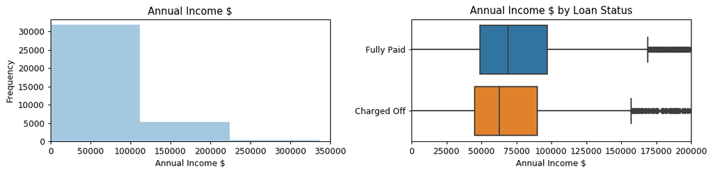

```python
plot_var('annual_inc', 'Annual Income $', continuous=True, dataset=dataset,
         x1limit=True, x2limit=True, x1l=-1, x1u=350000, x2l=-1, x2u=200000)
```

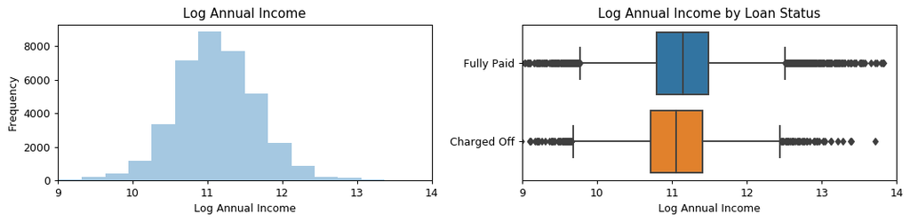

```python
plot_var('log_annual_inc', 'Log Annual Income', continuous=True, dataset=dataset,
         x1limit=True, x2limit=True, x1l=9, x1u=14, x2l=9, x2u=14)
```

It seems that those with higher annual income are less risk

### Installment (Numerical)

The monthly payment owed by the borrower if the loan originates.

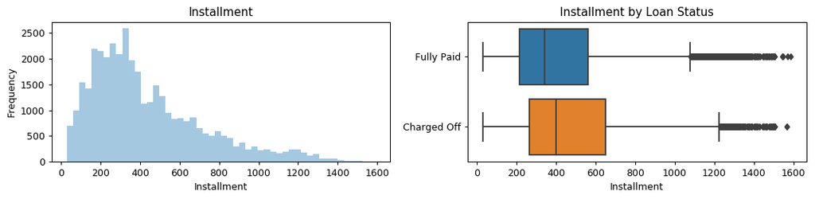

```python
plot_var('installment', 'Installment', continuous=True, dataset=dataset)
```

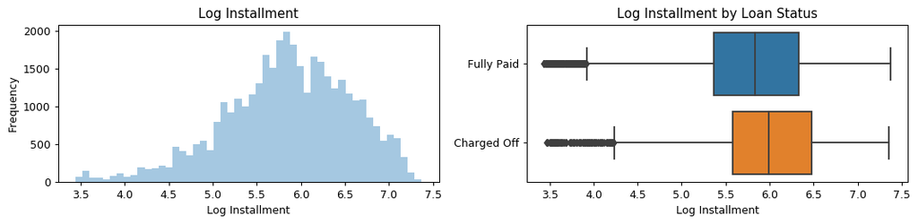

```python
plot_var('log_installment', 'Log Installment', continuous=True, dataset=dataset)
```

It seems those with higher installments are more likely to be charged off

### Interest Rate (Numerical)

Interest Rate on the loan

```
               count       mean       std   min    25%    50%    75%    max
loan_status
Charged Off   8625.0  16.636369  6.005821  5.32  12.62  15.05  19.03  30.99
Fully Paid   29145.0  13.215077  5.276465  5.32   9.93  12.62  15.99  30.99
```

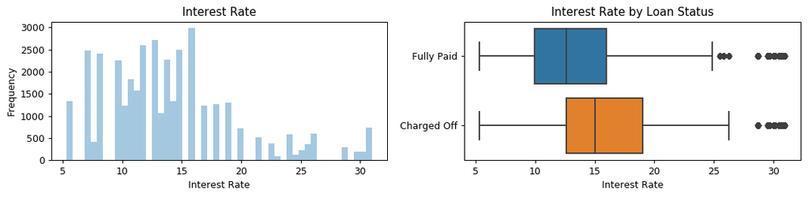

```python
dataset['int_rate'] = dataset['int_rate'].str.rstrip('%').astype('float')
print(dataset.groupby('loan_status')['int_rate'].describe())
plot_var('int_rate', 'Interest Rate', continuous=True, dataset=dataset)
```

There seems to be a much higher interest rate on average for loans that charge off

### Loan Amount (Numerical)

The listed amount of the loan applied for by the borrower. If at some point in time, the credit department reduces the loan amount, then it will be reflected in this value.

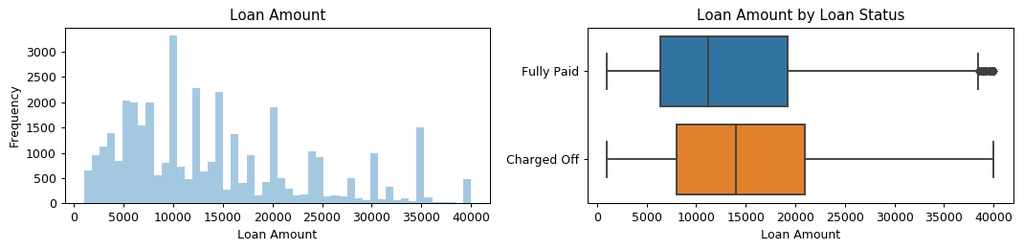

```python
plot_var('loan_amnt', 'Loan Amount', continuous=True, dataset=dataset)
```

It seems charged off loans have a higher loan amount

### Public Record (Categorical)

Number of derogatory public records

```
loan_status  pub_rec
Charged Off  None             6659
             At least one     1966
Fully Paid   None            22937
             At least one     6208
Name: pub_rec, dtype: int64
```

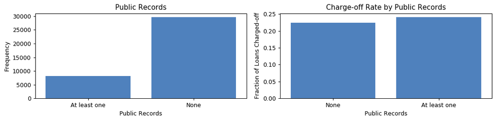

```python
dataset['pub_rec'] = pd.cut(dataset['pub_rec'], [0, 0.9, 25], labels=['None', 'At least one'], include_lowest=True)
print(dataset.groupby('loan_status')['pub_rec'].value_counts(dropna=False))
plot_var('pub_rec', 'Public Records', continuous=False, dataset=dataset)
```

Loan default rate does not seem to change much by derogatory public records

### Verification Status (Categorical)

Indicates if income was verified, not verified, or if the income source was verified.

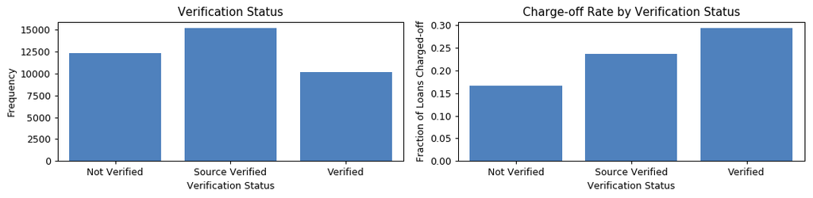

```python
plot_var('verification_status', 'Verification Status', continuous=False, dataset=dataset)
```

There seems to be a strong linear trend between charged off rate and verification status. Surprisingly, loans with a status of verified have a higher chance of becoming charged off.

# Feature Selection and Model Fitting

### Logistic Regression Model

```python
lr_model = LogisticRegression(penalty="l2",
                           C=0.5,
                           fit_intercept=True,
                           class_weight='balanced',
                           random_state=0,
                           max_iter=10000,
                           solver='lbfgs')
lr_model = lr_model.fit(x_train, y_train.values.ravel())
y_pred_lr = lr_model.predict(x_test)
```

```python
print('Accuracy of base logistic regresssion on test set: {:.3f}'.format(lr_model.score(x_test, y_test)))
conf_mat = confusion_matrix(y_test, y_pred_lr)
conf_mat
```

```
Accuracy of base logistic regresssion on test set: 0.657
```

```
array([[5542, 2687],
       [ 943, 1415]], dtype=int64)
```

```python
result.pvalues[result.pvalues > 0.05]
```

```
loan_amnt                            0.528648
grade_E                              0.135709
grade_F                              0.663670
grade_G                              0.776495
purpose_credit_card                  0.966228
purpose_debt_consolidation           0.979323
purpose_home_improvement             0.077484
purpose_major_purchase               0.289649
purpose_medical                      0.114448
purpose_moving                       0.051116
purpose_other                        0.104100
purpose_renewable_energy             0.117397
purpose_vacation                     0.079031
initial_list_status_w                0.460733
pub_rec_At least one                 0.756315
pub_rec_bankruptcies_At least one    0.881142
dtype: float64
```

### Logistic Regression Results

```python
print('Accuracy of adjusted logistic regresssion on test set: {:.3f}'.format(lr_model.score(x_test, y_test)))
conf_mat = confusion_matrix(y_test, y_pred_lr)
conf_mat
```

```
Accuracy of adjusted logistic regresssion on test set: 0.637
```

```
array([[5130, 3099],
       [ 739, 1619]], dtype=int64)
```

```python
print('F1 Score:', f1_score(y_test, y_pred_lr))
print(classification_report(y_test, y_pred_lr))
```

```
F1 Score: 0.4576031656302996
              precision    recall  f1-score   support

           0       0.87      0.62      0.73      8229
           1       0.34      0.69      0.46      2358

   micro avg       0.64      0.64      0.64     10587
   macro avg       0.61      0.66      0.59     10587
weighted avg       0.76      0.64      0.67     10587
```

### Random Forest Results

```python
print('Accuracy of Random Forest on test set: {:.3f}'.format(forest.score(x_test, y_test)))
conf_mat = confusion_matrix(y_test, y_pred_rf)
conf_mat
```

```
Accuracy of Random Forest on test set: 0.673
```

```
array([[5678, 2551],
       [ 914, 1444]], dtype=int64)
```

```python
print('F1 Score:', f1_score(y_test, y_pred_rf))
print(classification_report(y_test, y_pred_rf))
```

```
F1 Score: 0.45458838344089403
              precision    recall  f1-score   support

           0       0.86      0.69      0.77      8229
           1       0.36      0.61      0.45      2358

   micro avg       0.67      0.67      0.67     10587
   macro avg       0.61      0.65      0.61     10587
weighted avg       0.75      0.67      0.70     10587
```

### Ensembled Results

```python
conf_mat = confusion_matrix(y_test, y_pred_ensemble)
print(conf_mat)
print('Accuracy of ensemble on test set: {:.3f}'.format(ensemble.score(x_test, y_test.values.ravel())))
```

```
[[5413 2816]
 [ 838 1520]]
Accuracy of ensemble on test set: 0.655
```

# Production Use

### Input and Output Spec

- Input: pandas dataframe containing:
  - loan_status (Outcome)
  - Annual Income, Application Type, Debt to Income Ratio, Delinquincy, Earliest Credit Line, Employment Length, Home Ownership, Initial List Status, Installment, Interest Rate, Loan Amount, Mortgage Accounts, Open Account, Public Record, Public Record of Bankruptices, Purpose, Revolving Balance, Revolving Utility, Grade, Term, Total Accounts, Verification Status (Predictors)
- Outcome: list of same size as number of rows in pandas DataFrame containing:
  - 1/0 for predicted loan status of fully paid or charged off
  - Probability for each category

```python
input_data
```

|  | loan_amnt | term | int_rate | installment | grade | emp_length | home_ownership | annual_inc | verification_status | purpose | ... | earliest_cr_line | open_acc | pub_rec | revol_bal | revol_util | total_acc | initial_list_status | application_type | mort_acc | pub_rec_bankruptcies |
| --- | --- | --- | --- | --- | --- | --- | --- | --- | --- | --- | --- | --- | --- | --- | --- | --- | --- | --- | --- | --- | --- |
| 0 | 12000 | 36 months | 7.00% | 350 | A | 3 years | RENT | 30000 | Source Verified | major_purchase | ... | Jul-17 | 3 | 0 | 18000 | 17.24% | 3 | w | Individual | 0 | 0 |

1 rows × 22 columns

```python
input_data
```

|  | term | int_rate | emp_length | dti | delinq_2yrs | earliest_cr_line | open_acc | revol_util | total_acc | mort_acc | ... | grade_B | grade_C | grade_D | home_ownership_OWN | home_ownership_RENT | verification_status_Source Verified | verification_status_Verified | purpose_house | purpose_small_business | application_type_Joint App |
| --- | --- | --- | --- | --- | --- | --- | --- | --- | --- | --- | --- | --- | --- | --- | --- | --- | --- | --- | --- | --- | --- |
| 0 | 36 | 7.0 | 3 | 15.23 | 0 | 2017 | 3 | 17.24 | 3 | 0 | ... | 0 | 0 | 0 | 0 | 0 | 0 | 0 | 0 | 0 | 0 |

1 rows × 23 columns

```python
prod_model = load('.\\data\\ensemble_model.joblib')
output = prod_model.predict(input_data)
if output[0] == 0:
    print('Fully Paid')
else:
    print('Charged Off')
```

```
Fully Paid
```

```python
p_output
```

|  | Fully Paid | Charged Off |
| --- | --- | --- |
| 0 | 81% | 19% |

# Next Steps and Further Research

- Improve performance of current models
- Look into other ML models
- Improvemnts to feature selection
- Opportunity cost of prediction errors